# Quarto example

Draft analysis

By

Emile Latour

Date

December 7, 2023

## 1 Quarto

Quarto is based on Pandoc and uses its variation of markdown as its underlying document syntax. Pandoc markdown is an extended and slightly revised version of John Gruber’s Markdown syntax.

Markdown is a plain text format that is designed to be easy to write, and, even more importantly, easy to read.

[Good reference for html in quarto here](https://quarto.org/docs/reference/formats/html.html).

## 2 Running Code

```
[1] 2
```

```
[1] 4
```

| species | island | bill_length_mm | bill_depth_mm | flipper_length_mm | body_mass_g | sex | year |
| --- | --- | --- | --- | --- | --- | --- | --- |
| Adelie | Torgersen | 39.1 | 18.7 | 181 | 3,750 | male | 2,007 |
| Adelie | Torgersen | 39.5 | 17.4 | 186 | 3,800 | female | 2,007 |
| Adelie | Torgersen | 40.3 | 18.0 | 195 | 3,250 | female | 2,007 |
| Adelie | Torgersen | NA | NA | NA | NA | NA | 2,007 |
| Adelie | Torgersen | 36.7 | 19.3 | 193 | 3,450 | female | 2,007 |
| Adelie | Torgersen | 39.3 | 20.6 | 190 | 3,650 | male | 2,007 |

**Note**

Note that there are five types of callouts, including: `note`, `warning`, `important`, `tip`, and `caution`.

**Tip with Title**

This is an example of a callout with a title.

**Expand To Learn About Collapse**

This is an example of a ‘folded’ caution callout that can be expanded by the user. You can use `collapse="true"` to collapse it by default or `collapse="false"` to make a collapsible callout that is expanded by default.

**Pay Attention**

Using callouts is an effective way to highlight content that your reader give special consideration or attention.

**Pay Attention**

Using callouts is an effective way to highlight content that your reader give special consideration or attention.

**Pay Attention**

Using callouts is an effective way to highlight content that your reader give special consideration or attention.

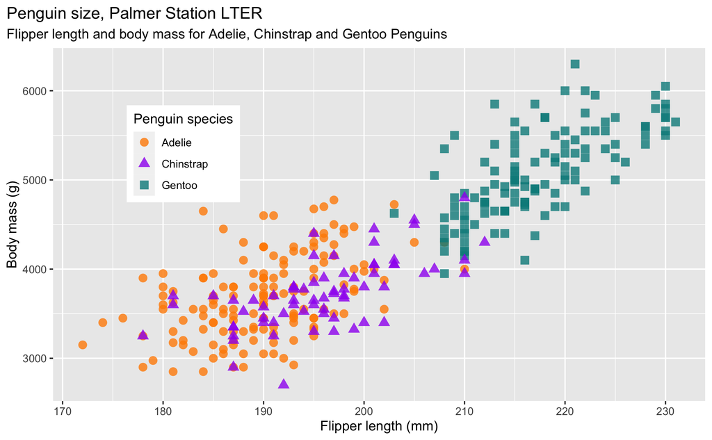

## 3 Tabset

**Penguin mass vs. flipper length**

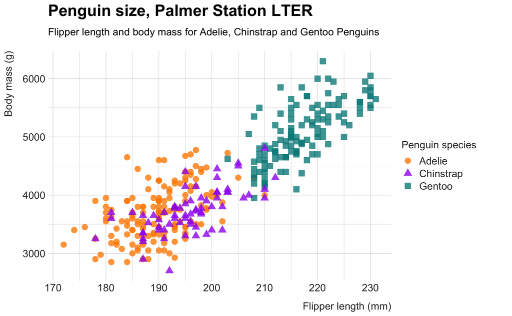

**Flipper length vs. bill length**

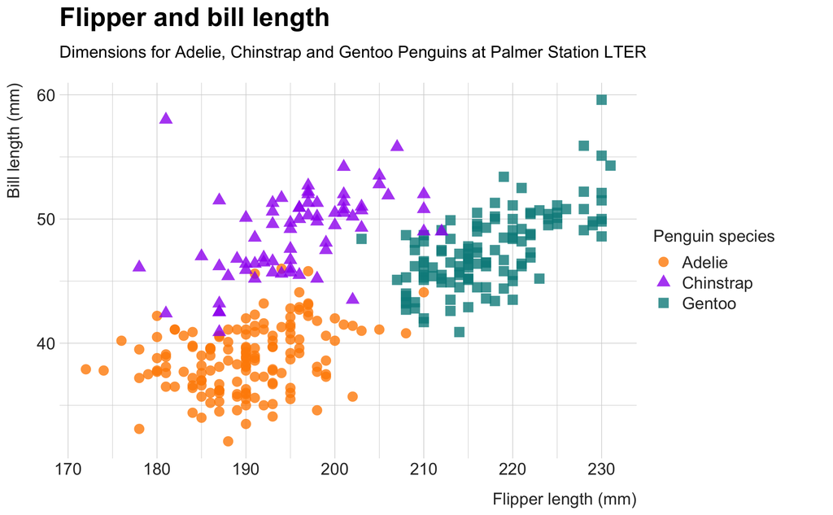